# Project 4-Description and Preliminary Analysis

Ilana Vinnik

2024-10-28

```r
library(tidyverse)
library(emmeans)
library(dplyr)
library(kableExtra)
```

```r
library(ggplot2)
library(tidyr)
library(scales)
library(knitr)
library(forcats)
```

```r
file_path <- "~/Desktop/Project 4/LeeDataFungalMorphogenesis.csv"
data <- read.csv(file_path)
colnames(data)
```

```
##  [1] "Pos..Control..No.Rx...A..A.SA..B..B.SB..combination.of.A.and.B..combination.of.SA.and.SB"
##  [2] "Replicate"
##  [3] "Slide..tube.....for.use.in.lab."
##  [4] "Response..No.change.in.morphology..No.GT..PH.or.buds."
##  [5] "Response..GT..germtubes..only"
##  [6] "Response..Pseudohypha..PH..only"
##  [7] "Response..Buds.only"
##  [8] "Response..GT...PH"
##  [9] "Response..GT...Buds"
## [10] "Response..PH...Buds"
## [11] "Response...1.GTs.multiple.GTs."
```

```r
# Rename specific columns using rename() from dplyr
data <- data %>%
  rename(
    Treatment = "Pos..Control..No.Rx...A..A.SA..B..B.SB..combination.of.A.and.B..combination.of.SA.and.SB",
    Replicate = "Replicate",
    Tube = "Slide..tube.....for.use.in.lab.",
    ResponseNoChange = "Response..No.change.in.morphology..No.GT..PH.or.buds.",
    ResponseGT = "Response..GT..germtubes..only",
    ResponsePH = "Response..Pseudohypha..PH..only",
    ResponseBuds = "Response..Buds.only",
    ResponseGTPH = "Response..GT...PH",
    ResponseGTBuds = "Response..GT...Buds",
    ResponsePHBuds = "Response..PH...Buds",
    ResponseGTMultiple = "Response...1.GTs.multiple.GTs."
  )
```

```r
# Calculate proportions for each response variable based on 200 total cells per replicate
data <- data %>%
  mutate(ResponseNoChangeProp = ResponseNoChange / 200,
         ResponseGTProp = ResponseGT / 200,
         ResponsePHProp = ResponsePH / 200,
         ResponseBudsProp = ResponseBuds / 200,
         ResponseGTPHProp = ResponseGTPH / 200,
         ResponseGTBudsProp = ResponseGTBuds / 200,
         ResponsePHBudsProp = ResponsePHBuds / 200,
         ResponseGTMultipleProp = ResponseGTMultiple / 200)
```

```r
summary_data <- data %>%
  group_by(Treatment) %>%
  summarise(
    MeanResponseGT = mean(ResponseGTProp),
    SDResponseGT = sd(ResponseGTProp),
    MeanResponseNoChange = mean(ResponseNoChangeProp),
    SDResponseNoChange = sd(ResponseNoChangeProp),
    MeanResponsePH = mean(ResponsePHProp),
    SDResponsePH = sd(ResponsePHProp),
    MeanResponseBuds = mean(ResponseBudsProp),
    SDResponseBuds = sd(ResponseBudsProp),
    MeanResponseGTPH = mean(ResponseGTPHProp),
    SDResponseGTPH = sd(ResponseGTPHProp),
    MeanResponseGTBuds = mean(ResponseGTBudsProp),
    SDResponseGTBuds = sd(ResponseGTBudsProp),
    MeanResponsePHBuds = mean(ResponsePHBudsProp),
    SDResponsePHBuds = sd(ResponsePHBudsProp),
    MeanResponseGTMultiple = mean(ResponseGTMultipleProp),
    SDResponseGTMultiple = sd(ResponseGTMultipleProp)
  ) %>%
  # Format mean ± SD for each response category
  mutate(
    GT = paste0(round(MeanResponseGT, 2), " ± ", round(SDResponseGT, 2)),
    NoChange = paste0(round(MeanResponseNoChange, 2), " ± ", round(SDResponseNoChange, 2)),
    PH = paste0(round(MeanResponsePH, 2), " ± ", round(SDResponsePH, 2)),
    Buds = paste0(round(MeanResponseBuds, 2), " ± ", round(SDResponseBuds, 2)),
    GTPH = paste0(round(MeanResponseGTPH, 2), " ± ", round(SDResponseGTPH, 2)),
    GTBuds = paste0(round(MeanResponseGTBuds, 2), " ± ", round(SDResponseGTBuds, 2)),
    PHBuds = paste0(round(MeanResponsePHBuds, 2), " ± ", round(SDResponsePHBuds, 2)),
    GTMultiple = paste0(round(MeanResponseGTMultiple, 2), " ± ", round(SDResponseGTMultiple, 2))
  )

# Print the formatted table using kableExtra
summary_data %>%
  select(Treatment, GT, NoChange, PH, Buds, GTPH, GTBuds, PHBuds, GTMultiple) %>%
  kable(align = "c", format = "html",
        col.names = c("Treatment", "Hyphae (GT)", "No Change", "Pseudohypha (PH)", "Buds",
                      "GT + PH", "GT + Buds", "PH + Buds", "> 1 GT"),
        caption = "Mean and Standard Deviation of Response Proportions by Treatment") %>%
  kable_styling(bootstrap_options = c("striped", "hover", "condensed", "responsive")) %>%
  add_header_above(c(" " = 1, "Mean ± SD (Proportion)" = 8))
```

Mean and Standard Deviation of Response Proportions by Treatment

| Treatment | Mean ± SD (Proportion) Hyphae (GT) | Mean ± SD (Proportion) No Change | Mean ± SD (Proportion) Pseudohypha (PH) | Mean ± SD (Proportion) Buds | Mean ± SD (Proportion) GT + PH | Mean ± SD (Proportion) GT + Buds | Mean ± SD (Proportion) PH + Buds | Mean ± SD (Proportion) > 1 GT |
| --- | --- | --- | --- | --- | --- | --- | --- | --- |
| No Treatment (positive control) | 0.85 ± 0.03 | 0.12 ± 0.04 | 0.01 ± 0.01 | 0.02 ± 0.01 | 0 ± 0 | 0 ± 0 | 0 ± 0 | 0 ± 0 |
| Whole Aloe arborescens Extract | 0.03 ± 0.01 | 0.93 ± 0.04 | 0.01 ± 0.01 | 0.04 ± 0.03 | 0 ± 0 | 0 ± 0 | 0 ± 0 | 0 ± 0 |
| combination of A and B | 0.09 ± 0.01 | 0.81 ± 0.06 | 0.07 ± 0.06 | 0 ± 0.01 | 0.01 ± 0.01 | 0.01 ± 0 | 0 ± 0 | 0 ± 0 |
| combination of A-SA and B-SA | 0.09 ± 0.02 | 0.74 ± 0.07 | 0.15 ± 0.05 | 0 ± 0.01 | 0 ± 0 | 0 ± 0 | 0.01 ± 0.01 | 0 ± 0 |
| compound ‘A’ isolated from Aloe arborescens | 0.07 ± 0.02 | 0.62 ± 0.06 | 0.14 ± 0.02 | 0.06 ± 0.02 | 0 ± 0 | 0.05 ± 0.02 | 0.04 ± 0.01 | 0.02 ± 0.01 |
| compound ‘A-SA’ from Sigma Aldrich | 0.05 ± 0.02 | 0.69 ± 0.05 | 0.14 ± 0.02 | 0.03 ± 0.02 | 0 ± 0 | 0.05 ± 0.02 | 0.03 ± 0.01 | 0.01 ± 0.01 |
| compound ‘B’ isolated from Aloe arborescens | 0.12 ± 0.04 | 0.69 ± 0.06 | 0.07 ± 0.02 | 0.05 ± 0.02 | 0 ± 0.01 | 0.03 ± 0.01 | 0.01 ± 0.01 | 0.02 ± 0.01 |
| compound ‘B-SA’ from Sigma Aldrich | 0.22 ± 0.06 | 0.61 ± 0.08 | 0.09 ± 0.05 | 0.04 ± 0.01 | 0 ± 0 | 0.01 ± 0.02 | 0.01 ± 0.01 | 0.01 ± 0.01 |

```r
# Summary statistics for each treatment group
data %>%
  group_by(Treatment) %>%
  summarise(
    Mean = mean(ResponseGTProp * 100, na.rm = TRUE),
    Median = median(ResponseGTProp * 100, na.rm = TRUE),
    SD = sd(ResponseGTProp * 100, na.rm = TRUE),
    Min = min(ResponseGTProp * 100, na.rm = TRUE),
    Max = max(ResponseGTProp * 100, na.rm = TRUE)
  ) %>%
  kable("html", caption = "Summary Statistics of Hyphal Formation by Treatment") %>%
  kable_styling()
```

Summary Statistics of Hyphal Formation by Treatment

| Treatment | Mean | Median | SD | Min | Max |
| --- | --- | --- | --- | --- | --- |
| No Treatment (positive control) | 85.0 | 86.5 | 3.409545 | 79.5 | 88.0 |
| Whole Aloe arborescens Extract | 3.0 | 3.5 | 1.172604 | 1.5 | 4.0 |
| combination of A and B | 8.9 | 8.5 | 1.083974 | 8.0 | 10.5 |
| combination of A-SA and B-SA | 8.5 | 8.5 | 2.150581 | 6.0 | 11.5 |
| compound ‘A’ isolated from Aloe arborescens | 6.9 | 6.5 | 2.484955 | 4.0 | 10.5 |
| compound ‘A-SA’ from Sigma Aldrich | 5.4 | 5.0 | 2.043282 | 3.0 | 8.5 |
| compound ‘B’ isolated from Aloe arborescens | 12.2 | 12.0 | 3.817722 | 7.0 | 17.0 |
| compound ‘B-SA’ from Sigma Aldrich | 22.1 | 19.0 | 5.661272 | 18.0 | 31.0 |

```r
# Reshape data to long format to include all response categories
long_summary_data <- summary_data %>%
  select(Treatment, MeanResponseGT, MeanResponseNoChange, MeanResponsePH, MeanResponseBuds,
         MeanResponseGTPH, MeanResponseGTBuds, MeanResponsePHBuds, MeanResponseGTMultiple) %>%
  pivot_longer(cols = starts_with("Mean"), names_to = "ResponseType", values_to = "Proportion") %>%
  mutate(ResponseType = recode(ResponseType,
                               "MeanResponseGT" = "Hyphae (GT)",
                               "MeanResponseNoChange" = "No GT, No PH, No Buds",
                               "MeanResponsePH" = "Pseudohypha (PH)",
                               "MeanResponseBuds" = "Buds",
                               "MeanResponseGTPH" = "GT + PH",
                               "MeanResponseGTBuds" = "GT + Buds",
                               "MeanResponsePHBuds" = "PH + Buds",
                               "MeanResponseGTMultiple" = "> 1 GT"),
         # Calculate percentage for display
         Percentage = Proportion * 100)
```

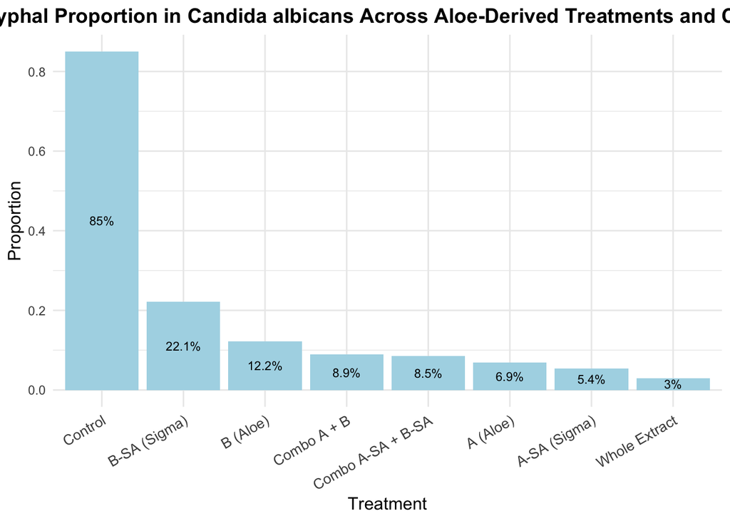

```r
# ggplot code with ordered treatment names by hyphal percentage specifically for "Hyphae (GT)"
ggplot(long_summary_data %>% filter(ResponseType == "Hyphae (GT)"),
       aes(x = fct_reorder(Treatment, Percentage, .desc = TRUE),
           y = Proportion, fill = ResponseType)) +
  geom_bar(stat = "identity") +
  geom_text(aes(label = paste0(round(Percentage, 1), "%")),
            position = position_stack(vjust = 0.5), color = "black", size = 3) +
  labs(title = "Hyphal Proportion in Candida albicans Across Aloe-Derived Treatments and Control",
       y = "Proportion", x = "Treatment") +
  scale_fill_manual(values = c("Hyphae (GT)" = "lightblue",
                               "No GT, No PH, No Buds" = "#FFA07A",
                               "Pseudohypha (PH)" = "#FFD700",
                               "Buds" = "#90EE90",
                               "GT + PH" = "#20B2AA",
                               "GT + Buds" = "#FF6347",
                               "PH + Buds" = "#BA55D3",
                               "> 1 GT" = "#708090")) +
  scale_x_discrete(labels = c("combination of A and B" = "Combo A + B",
                              "combination of A-SA and B-SA" = "Combo A-SA + B-SA",
                              "compound 'A-SA' from Sigma Aldrich" = "A-SA (Sigma)",
                              "compound 'A' isolated from Aloe arborescens" = "A (Aloe)",
                              "compound 'B-SA' from Sigma Aldrich" = "B-SA (Sigma)",
                              "compound 'B' isolated from Aloe arborescens" = "B (Aloe)",
                              "No Treatment (positive control)" = "Control",
                              "Whole Aloe arborescens Extract" = "Whole Extract")) +
  theme_minimal() +
  theme(axis.text.x = element_text(angle = 30, hjust = 1, size = 10),
        legend.position = "",
        plot.title = element_text(face = "bold", size = 14, hjust = 0.5),
        plot.subtitle = element_text(size = 10),
        axis.title = element_text(size = 12),
        legend.title = element_blank())
```

Figure 1: This chart shows the big picture of the proportion of hyphae in each applied treatment and control. The untreated control has the highest proportion of hyphal formation, while all treatments exhibit reductions in hyphal growth, with the “Whole Aloe arborescens Extract” showing the most significant decrease.

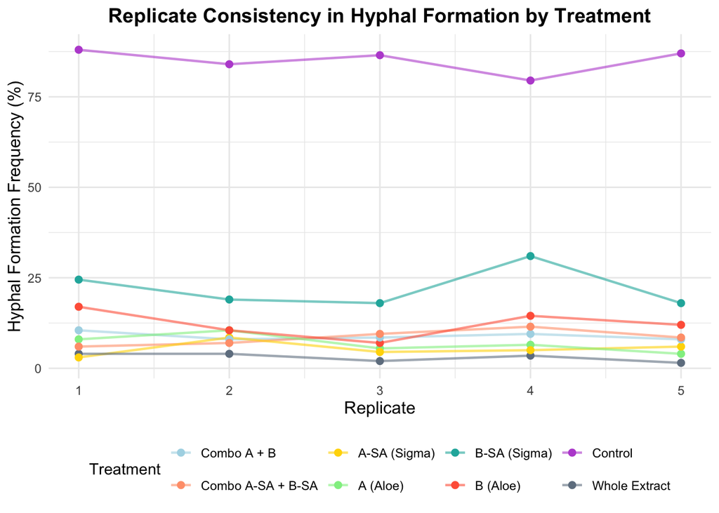

```r
# Line Plot to check consistency across replicates for each treatment
ggplot(data, aes(x = Replicate, y = ResponseGTProp * 100, color = Treatment, group = Treatment)) +
  geom_line(alpha = 0.6, size = 0.8) +
  geom_point(size = 2) +
  labs(title = "Replicate Consistency in Hyphal Formation by Treatment",
       x = "Replicate",
       y = "Hyphal Formation Frequency (%)") +
  scale_color_manual(values = c(
      "combination of A and B" = "lightblue",
      "combination of A-SA and B-SA" = "#FFA07A",
      "compound 'A-SA' from Sigma Aldrich" = "#FFD700",
      "compound 'A' isolated from Aloe arborescens" = "#90EE90",
      "compound 'B-SA' from Sigma Aldrich" = "#20B2AA",
      "compound 'B' isolated from Aloe arborescens" = "#FF6347",
      "No Treatment (positive control)" = "#BA55D3",
      "Whole Aloe arborescens Extract" = "#708090"
  ),
  labels = c(
      "combination of A and B" = "Combo A + B",
      "combination of A-SA and B-SA" = "Combo A-SA + B-SA",
      "compound 'A-SA' from Sigma Aldrich" = "A-SA (Sigma)",
      "compound 'A' isolated from Aloe arborescens" = "A (Aloe)",
      "compound 'B-SA' from Sigma Aldrich" = "B-SA (Sigma)",
      "compound 'B' isolated from Aloe arborescens" = "B (Aloe)",
      "No Treatment (positive control)" = "Control",
      "Whole Aloe arborescens Extract" = "Whole Extract"
  )) +
  theme_minimal() +
  theme(axis.text.x = element_text(angle = 0, hjust = 0.5),
        legend.position = "bottom",
        plot.title = element_text(face = "bold", size = 14, hjust = 0.5),
        axis.title = element_text(size = 12))
```

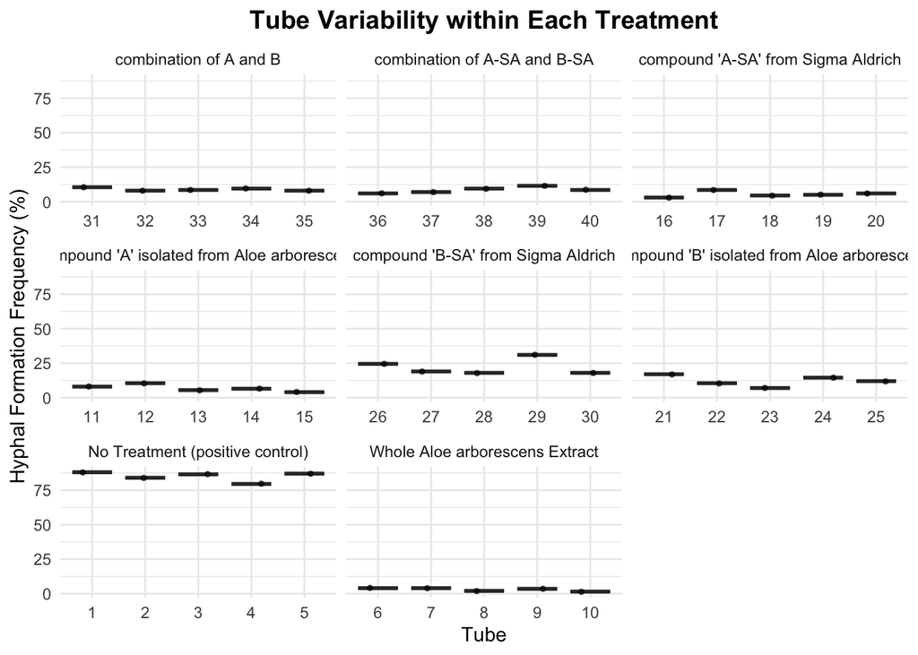

```r
# Faceted box plot to check tube consistency within each treatment
ggplot(data, aes(x = as.factor(Tube), y = ResponseGTProp * 100, fill = as.factor(Tube))) +
  geom_boxplot(outlier.shape = NA, alpha = 0.7) +
  geom_jitter(color = "black", size = 1, width = 0.2, alpha = 0.6) +
  labs(title = "Tube Variability within Each Treatment",
       x = "Tube",
       y = "Hyphal Formation Frequency (%)",
       fill = "Tube") +
  facet_wrap(~ Treatment, scales = "free_x") +
  theme_minimal() +
  theme(
    plot.title = element_text(face = "bold", size = 14, hjust = 0.5), # Center and bold title
    axis.text.x = element_text(angle = 0, hjust = 0.5),
    legend.position = "none"
  )
```

Figure 3: This plot evaluates tube-to-tube variability in hyphal formation frequency within each treatment. Overall, the tubes display consistent responses, indicating reliable measurements within treatment groups. Notably, in “compound B-SA from Sigma Aldrich,” Tube 29 shows a slight increase in hyphal formation frequency compared to other tubes, suggesting a minor variation that may warrant further examination.

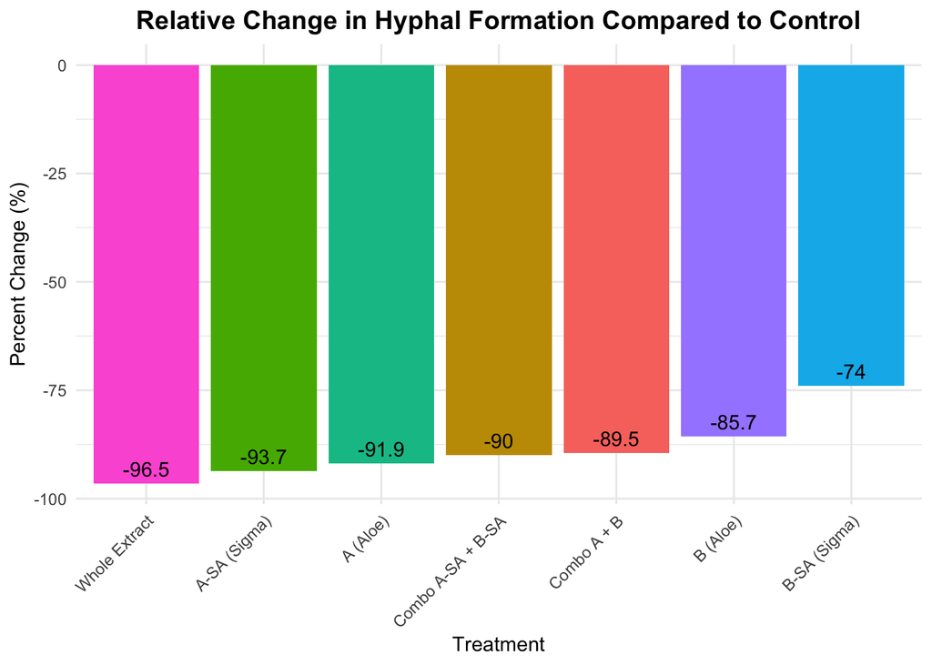

```r
# Summarize mean and standard deviation of GT response for each treatment
summary_data <- data %>%
  group_by(Treatment) %>%
  summarise(
    MeanResponseGT = mean(ResponseGTProp, na.rm = TRUE),
    SDResponseGT = sd(ResponseGTProp, na.rm = TRUE)
  )

# Calculate mean GT response for Control
control_hyphae_value <- summary_data$MeanResponseGT[summary_data$Treatment == "No Treatment (positive control)"]

# Calculate percent change of hyphae compared to Control
summary_data <- summary_data %>%
  mutate(
    Hyphae_PercentChange_Control = (MeanResponseGT - control_hyphae_value) / control_hyphae_value * 100
  )

# Convert columns to formatted strings with mean ± SD
summary_data <- summary_data %>%
  mutate(
    GT = paste0(round(MeanResponseGT, 2), " ± ", round(SDResponseGT, 2)),
    Hyphae_PercentChange_Control = round(Hyphae_PercentChange_Control, 2)
  )

# Filter out the "No Treatment" for the plot
filtered_summary_data <- summary_data %>%
  filter(Treatment != "No Treatment (positive control)")

# Bar Plot for Percent Change Relative to Control
ggplot(filtered_summary_data, aes(x = fct_reorder(Treatment, Hyphae_PercentChange_Control),
                                  y = Hyphae_PercentChange_Control,
                                  fill = Treatment)) +
  geom_bar(stat = "identity") +
  geom_text(aes(label = round(Hyphae_PercentChange_Control, 1)),
            vjust = -0.5,  # Position text above the bar
            color = "black") +
  labs(title = "Relative Change in Hyphal Formation Compared to Control",
       x = "Treatment",
       y = "Percent Change (%)") +
  scale_x_discrete(labels = c(
      "combination of A and B" = "Combo A + B",
      "combination of A-SA and B-SA" = "Combo A-SA + B-SA",
      "compound 'A-SA' from Sigma Aldrich" = "A-SA (Sigma)",
      "compound 'A' isolated from Aloe arborescens" = "A (Aloe)",
      "compound 'B-SA' from Sigma Aldrich" = "B-SA (Sigma)",
      "compound 'B' isolated from Aloe arborescens" = "B (Aloe)",
      "Whole Aloe arborescens Extract" = "Whole Extract"
  )) +
  theme_minimal() +
  theme(
    plot.title = element_text(face = "bold", size = 14, hjust = 0.5), # Center and bold title
    axis.text.x = element_text(angle = 45, hjust = 1),
    legend.position = "none"  # Remove legend
  )
```

Figure 4: This bar plot shows the percent reduction in hyphal formation for each treatment relative to the untreated control. The “Whole Aloe arborescens Extract” exhibits the most substantial decrease at -96.5%, followed by “A-SA (Sigma)” and “A (Aloe)” treatments. Treatments containing compound B, particularly “B-SA (Sigma),” show a comparatively smaller reduction, indicating lower effectiveness in inhibiting hyphal growth

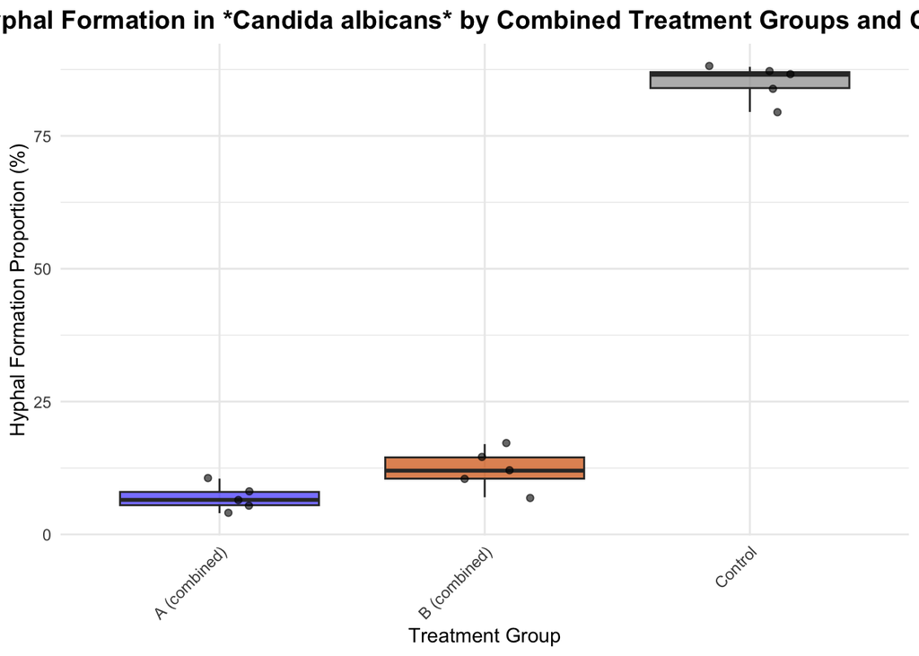

```r
# Reclassify treatments into combined groups
data_combined <- data %>%
  mutate(Treatment_Group = case_when(
    Treatment %in% c("compound 'A' isolated from Aloe arborescens",
                     "compound 'A-SA' purchased from Sigma-Aldrich Company") ~ "A (combined)",
    Treatment %in% c("compound 'B' isolated from Aloe arborescens",
                     "compound 'B-SA' purchased from Sigma-Aldrich Company") ~ "B (combined)",
    Treatment == "No Treatment (positive control)" ~ "Control"
  ))

# Filter the data to only include the combined groups
data_combined <- data_combined %>% filter(Treatment_Group %in% c("A (combined)", "B (combined)", "Control"))

# Create the box plot with combined groups
ggplot(data_combined, aes(x = Treatment_Group, y = ResponseGTProp * 100, fill = Treatment_Group)) +
  geom_boxplot(alpha = 0.7, outlier.shape = NA) +  # Box plot without outliers for a cleaner look
  geom_jitter(color = "black", size = 1.5, width = 0.2, alpha = 0.6) +  # Add individual data points as jittered dots
  labs(title = "Hyphal Formation in *Candida albicans* by Combined Treatment Groups and Control",
       x = "Treatment Group",
       y = "Hyphal Formation Proportion (%)") +
  scale_fill_manual(values = c("A (combined)" = "#4D4DFF",
                               "B (combined)" = "#D55E00",
                               "Control" = "#999999")) +
  theme_minimal() +
  theme(
    plot.title = element_text(face = "bold", size = 14, hjust = 0.5),  # Center and bold title
    axis.text.x = element_text(angle = 45, hjust = 1),  # Rotate x-axis labels for clarity
    legend.position = "none"  # Remove legend for simplicity
  )
```

# Plan to do for the final/full analysis:

This analysis employs orthogonal contrasts to examine the impact of various treatments on hyphal formation in Candida albicans, focusing on testing each hypothesis independently while minimizing Type I error rates associated with multiple comparisons. Orthogonal contrasts ensure that each comparison is distinct and non-overlapping, allowing for a robust interpretation of the treatment effects on hyphal formation.

For the first hypothesis, a contrast vector [-7, 1, 1, 1, 1, 1, 1, 1] was defined to compare the untreated control group to the seven treatment groups combined. Here, the control is assigned a weight of -7, while each treatment group receives a weight of 1. This contrast tests whether the treatments as a group reduce hyphal formation relative to the control.

In the second hypothesis, the contrast vector [0, 0, 1, 1, -1, -1, 0, 0] compares the effectiveness of treatments containing Compound A to those containing Compound B. Treatments containing Compound A receive a weight of 1, those with Compound B are assigned -1, and other treatments are excluded from the comparison with a weight of 0. This setup tests if treatments with Compound A reduce hyphal formation more than those with Compound B.

For the third hypothesis, the contrast vector [0, 6, -1, -1, -1, -1, -1, -1] was constructed to isolate the Aloe extract treatment and compare it against all other treatments combined. The Aloe extract treatment is given a weight of 6, while all other treatments receive a weight of -1. This contrast tests if the Aloe extract has a uniquely distinct impact on hyphal formation compared to the other treatments.

```r
# Define the orthogonal contrast matrix
contrast_matrix <- matrix(c(
    -7,  1,  1,  1,  1,  1,  1,  1,    # Control vs. All Treatments
     0,  0,  1,  1, -1, -1,  0,  0,    # Compound A vs Compound B
     0,  6, -1, -1, -1, -1, -1, -1     # Aloe Extract vs. Other Treatments
), ncol = 3, byrow = FALSE)

# Assign contrast names to the matrix
colnames(contrast_matrix) <- c("Control_vs_AllTreatments", "CompoundA_vs_CompoundB", "Aloe_vs_Others")

# Check orthogonality by calculating pairwise products (dot products)
orthogonality_check <- t(contrast_matrix) %*% contrast_matrix
print("Orthogonality Check:")
```

```
## [1] "Orthogonality Check:"
```

```r
print(orthogonality_check)
```

```
##                          Control_vs_AllTreatments CompoundA_vs_CompoundB
## Control_vs_AllTreatments                       56                      0
## CompoundA_vs_CompoundB                          0                      4
## Aloe_vs_Others                                  0                      0
##                          Aloe_vs_Others
## Control_vs_AllTreatments              0
## CompoundA_vs_CompoundB                0
## Aloe_vs_Others                       42
```

Below is a sample code to set up the orthogonal contrast matrix and perform the planned analysis. This code demonstrates the approach without running inferential tests, as the intention is only to outline the analysis plan.

## Sample Code for Future Plan

```r
# Ensure 'Treatment' is a factor with specified levels
data$Treatment <- factor(data$Treatment,
                         levels = c("No Treatment (positive control)",
                                    "Whole Aloe arborescens Extract",
                                    "compound 'A' isolated from Aloe arborescens",
                                    "compound 'A-SA' from Sigma Aldrich",
                                    "compound 'B' isolated from Aloe arborescens",
                                    "compound 'B-SA' from Sigma Aldrich",
                                    "combination of A and B",
                                    "combination of A-SA and B-SA"))


# Define the orthogonal contrast matrix
contrast_matrix <- matrix(c(
    -7,  1,  1,  1,  1,  1,  1,  1,    # Control vs. All Treatments
     0,  0,  1,  1, -1, -1,  0,  0,    # Compound A vs Compound B
     0,  6, -1, -1, -1, -1, -1, -1     # Aloe Extract vs. Other Treatments
), ncol = 3, byrow = FALSE)

# Assign contrast names to the matrix
colnames(contrast_matrix) <- c("Control_vs_AllTreatments", "CompoundA_vs_CompoundB", "Aloe_vs_Others")

# Apply the contrasts explicitly using the `contrasts<-` function
contrasts(data$Treatment) <- contrast_matrix

# Fit the model with the specified contrasts
model <- lm(ResponseGTProp ~ Treatment, data = data)
```